# Assignment 6

Janice Luong  
STA 141B  
March 19, 2017

In this assignment, you'll analyze a collection of data sets from the [San Francisco Open Data Portal](http://data.sfgov.org/) and [Zillow](https://www.zillow.com/). The data sets have been stored in the SQLite database `sf_data.sqlite`, which you can [download here](http://anson.ucdavis.edu/~nulle/sf_data.sqlite). The database contains the following tables:

| Table | Description |
| --- | --- |
| `crime` | Crime reports dating back to 2010. |
| `mobile_food_locations` | List of all locations where mobile food vendors sell. |
| `mobile_food_permits` | List of all mobile food vendor permits. More details [here](https://data.sfgov.org/api/views/rqzj-sfat/files/8g2f5RV4PEk0_b24iJEtgEet9gnh_eA27GlqoOjjK4k?download=true&filename=DPW_DataDictionary_Mobil… |
| `mobile_food_schedule` | Schedules for mobile food vendors. |
| `noise` | Noise complaints dating back to August 2015. |
| `parking` | List of all parking lots. |
| `parks` | List of all parks. |
| `schools` | List of all schools. |
| `zillow` | Zillow rent and housing statistics dating back to 1996. More details [here](https://www.zillow.com/research/data/). |

The `mobile_food_` tables are explicitly connected through the `locationid` and `permit` columns. The other tables are not connected, but you may be able to connect them using dates, latitude/longitude, or postal codes.

Shapefiles for US postal codes are available [here](https://www.census.gov/geo/maps-data/data/cbf/cbf_zcta.html). These may be useful for converting latitude/longitude to postal codes.

Shapefiles for San Francisco Neighborhoods are available [here](https://data.sfgov.org/Geographic-Locations-and-Boundaries/SF-Find-Neighborhoods/pty2-tcw4).

I worked with Richard Safran, Chad Pickering and Edie Espejo.

**Exercise 1.1.** Which mobile food vendor(s) sells at the most locations?

```python
import sqlite3
import pandas as pd
import matplotlib.pyplot as plt
import seaborn as sns
import shapely.geometry as geom
import geopandas as gpd
import matplotlib.patches as mpatches
import warnings
warnings.filterwarnings('ignore')

# Make Jupyter to automatically display matplotlib plots.
%matplotlib inline

from mpl_toolkits.basemap import Basemap
import numpy as np
from math import log
```

```python
# Reads database
db = sqlite3.connect("sf_data.sqlite")
```

```python
pd.read_sql("SELECT * FROM sqlite_master", db)
```

|  | type | name | tbl_name | rootpage | sql |
| --- | --- | --- | --- | --- | --- |
| 0 | table | crime | crime | 2 | CREATE TABLE "crime" (\n"IncidntNum" INTEGER,\... |
| 1 | table | noise | noise | 35775 | CREATE TABLE "noise" (\n"CaseID" INTEGER,\n "... |
| 2 | table | parking | parking | 35921 | CREATE TABLE "parking" (\n"Owner" TEXT,\n "Ad... |
| 3 | table | schools | schools | 35944 | CREATE TABLE "schools" (\n"Name" TEXT,\n "Ent... |
| 4 | table | parks | parks | 35961 | CREATE TABLE "parks" (\n"Name" TEXT,\n "Type"... |
| 5 | table | zillow | zillow | 35967 | CREATE TABLE "zillow" (\n"RegionName" INTEGER,... |
| 6 | table | mobile_food_permits | mobile_food_permits | 36050 | CREATE TABLE "mobile_food_permits" (\n"permit"... |
| 7 | table | mobile_food_locations | mobile_food_locations | 36060 | CREATE TABLE "mobile_food_locations" (\n"locat... |
| 8 | table | mobile_food_schedule | mobile_food_schedule | 36079 | CREATE TABLE "mobile_food_schedule" (\n"locati... |

```python
most_location_mobile = pd.read_sql("SELECT p.Applicant, \
                                   COUNT(s.locationid) as 'Unique Locations', Status \
                                   FROM mobile_food_permits p \
                                   INNER JOIN mobile_food_schedule s ON p.permit = s.permit \
                                   WHERE p.Status = 'APPROVED' \
                                   GROUP BY Applicant \
                                   ORDER BY COUNT(s.locationid) \
                                   DESC \
                                   LIMIT 15", db)
most_location_mobile
```

|  | Applicant | Unique Locations | Status |
| --- | --- | --- | --- |
| 0 | Park's Catering | 134 | APPROVED |
| 1 | D & T Catering | 85 | APPROVED |
| 2 | F & C Catering | 79 | APPROVED |
| 3 | Munch A Bunch | 52 | APPROVED |
| 4 | BH & MT LLC | 40 | APPROVED |
| 5 | Linda's Catering | 35 | APPROVED |
| 6 | San Francisco Carts & Concessions, Inc. DBA St... | 35 | APPROVED |
| 7 | Golden Catering | 31 | APPROVED |
| 8 | Eva's Catering | 22 | APPROVED |
| 9 | Subs on Hubs | 19 | APPROVED |
| 10 | Tacos Rodriguez | 17 | APPROVED |
| 11 | DO UC US Mobile Catering | 16 | APPROVED |
| 12 | Bay Area Mobile Catering, Inc. dba. Taqueria A... | 15 | APPROVED |
| 13 | El Tonayense #60 | 14 | APPROVED |
| 14 | Roadside Rotisserie Corporation / Country Grill | 12 | APPROVED |

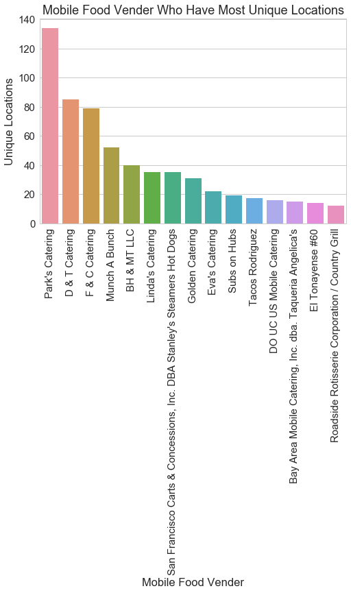

```python
# Set the size of plot or else its too small to read
plt.rcParams['figure.figsize'] = (10, 10)
sns.set(font_scale = 1.5)

sns.set_style("whitegrid")
mobile_locat = sns.barplot(x = "Applicant", y = "Unique Locations", data = most_location_mobile)
for item in mobile_locat.get_xticklabels():
    item.set_rotation(90)
sns.plt.title('Mobile Food Vender Who Have Most Unique Locations')
mobile_locat.set(ylabel = 'Unique Locations', xlabel = 'Mobile Food Vender')
sns.plt.show()
```

The food venders that sell at the most locations are Park's Catering, D & T Catering, F & C Catering, Munch A Bunch, BH & MT LLC, Linda's Catering, and San Francisco Carts & Concessions, Inc.

**Exercise 1.2.** Ask and use the database to analyze 5 questions about San Francisco. For each question, write at least 150 words and support your answer with plots. Make a map for at least 2 of the 5 questions.

You should try to come up with some questions on your own, but these are examples of reasonable questions:

- Which parts of the city are the most and least expensive?
- Which parts of the city are the most dangerous (and at what times)?
- Are noise complaints and mobile food vendors related?
- What are the best times and places to find food trucks?
- Is there a relationship between housing prices and any of the other tables?

Please make sure to clearly state each of your questions in your submission.

### 1. Which parts of the city are the most and least expensive?

```python
ratio_rent_zip = pd.read_sql("SELECT AVG(PriceToRentRatio_AllHomes) as 'Price to Rent Ratio', RegionName as 'Zipcode' \
                             FROM zillow \
                             WHERE PriceToRentRatio_AllHomes IS NOT NULL \
                             GROUP BY RegionName \
                             ORDER BY AVG(PriceToRentRatio_AllHomes) \
                             DESC", db)
ratio_rent_zip.head()
```

|  | Price to Rent Ratio | Zipcode |
| --- | --- | --- |
| 0 | 26.086711 | 94123 |
| 1 | 23.930658 | 94114 |
| 2 | 23.869211 | 94127 |
| 3 | 22.997500 | 94121 |
| 4 | 22.725921 | 94131 |

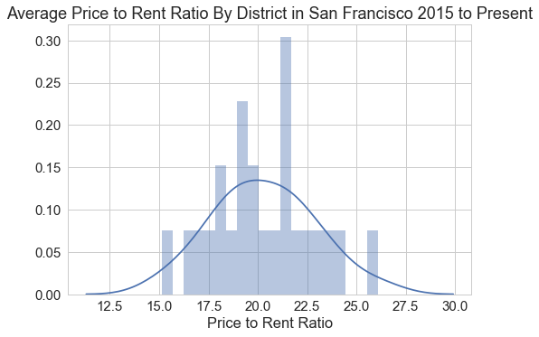

```python
sns.distplot(ratio_rent_zip['Price to Rent Ratio'], bins=20)
sns.plt.title('Average Price to Rent Ratio By District in San Francisco 2015 to Present')
plt.show()
```

For my querie, I selected the PriceToRentRation_AllHomes column because the PriceToRentRation_AllHomes is calculated as the ratio of home prices to annual rental rates. So, for example, in a real estate market where, on average, a home worth \$200,000 could rent for \$1000 a month, the price-rent ratio is 16.67. That's determined using the formula: $\$200,000 ÷ (12 \times \$1,000)$. So this column would give me a general idea how expensive or cheap an area in San Francisco are because the more a home is worth, the home's price-rent ratio would be higher.

For each zipcode, I took the average of the price to rent ratio so I could get an idea of how high or low the rent in San Francisco is. Since the price to rent ratio is derived from the house's real estate market, we know that if the price to rent ratio is higher for certain areas, then that means the house has a higher value. And vice versa for areas with a low price to rent ratio.

However, on issue I did notice with the price-rent ratio is that areas such as Soma, Financial District and South Beach do not appear at the top of the list for most expensive areas to live in San Francisco because most of the residents there live in apartments and apartments are generally cheaper to rent than compared to rending a house in the Marina District. However the areas such as the Marina the Castro, North Beach, and Pacific Heights are still areas of San Francisco that are more expensive to rent.

```python
rent_zip = pd.read_sql("SELECT PriceToRentRatio_AllHomes as 'Price to Rent Ratio', RegionName as 'Zipcode' \
                       FROM zillow \
                       WHERE PriceToRentRatio_AllHomes IS NOT NULL", db)
```

There were some Price to rent ratios that were empty, I removed those because they would not add anything meaningful to my histogram.

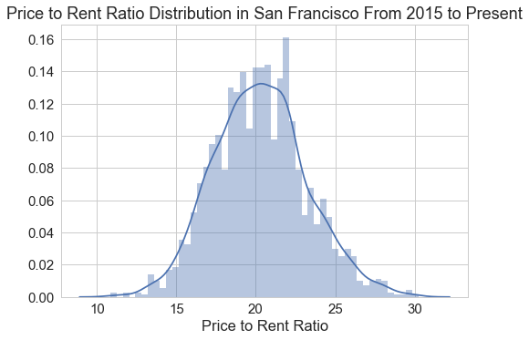

```python
sns.distplot(rent_zip['Price to Rent Ratio'], bins=50)
sns.plt.title('Price to Rent Ratio Distribution in San Francisco From 2015 to Present')
plt.show()
```

### 2. Which parts of the city are the most dangerous (and at what times)?

```python
pd.read_sql("SELECT Lon, Lat, PdDistrict, strftime('%H', Datetime) as 'Hour of the Day', COUNT(*) as 'PdDistCount' \
            FROM crime \
            WHERE PdDistrict IS NOT NULL \
            GROUP BY PdDistrict, Datetime \
            ORDER BY COUNT(*) \
            DESC \
            LIMIT 10"
                  , db)
```

|  | Lon | Lat | PdDistrict | Hour of the Day | PdDistCount |
| --- | --- | --- | --- | --- | --- |
| 0 | -122.402672 | 37.756423 | BAYVIEW | 00 | 48 |
| 1 | -122.404286 | 37.796142 | CENTRAL | 11 | 35 |
| 2 | -122.422063 | 37.789920 | NORTHERN | 12 | 34 |
| 3 | -122.476057 | 37.762657 | TARAVAL | 12 | 34 |
| 4 | -122.408761 | 37.715900 | INGLESIDE | 00 | 26 |
| 5 | -122.401817 | 37.788441 | SOUTHERN | 12 | 26 |
| 6 | -122.403405 | 37.775421 | SOUTHERN | 00 | 23 |
| 7 | -122.397251 | 37.778980 | SOUTHERN | 00 | 22 |
| 8 | -122.474308 | 37.716643 | TARAVAL | 12 | 22 |
| 9 | -122.419059 | 37.759423 | MISSION | 00 | 21 |

```python
crime_location = pd.read_sql("SELECT Lon, Lat, PdDistrict, COUNT(*) as 'PdDistCount' \
                             FROM crime \
                             WHERE PdDistrict IS NOT NULL \
                             GROUP BY PdDistrict, Lon \
                             ORDER BY COUNT(*) \
                             DESC \
                             LIMIT 2000"
                             , db)
crime_location.head()
```

|  | Lon | Lat | PdDistrict | PdDistCount |
| --- | --- | --- | --- | --- |
| 0 | -122.403405 | 37.775421 | SOUTHERN | 30673 |
| 1 | -122.406539 | 37.756486 | MISSION | 4631 |
| 2 | -122.419672 | 37.765050 | MISSION | 4580 |
| 3 | -122.407634 | 37.784189 | SOUTHERN | 4410 |
| 4 | -122.419658 | 37.764221 | MISSION | 3497 |

I will use this query to plot what parts of the city are most dangerous. I grouped by police district so I could get all the number of crimes that police station has gotten since 2010. Then I grouped by the longitide (could have also done latitude) so that way I can get the unique locations of where all crimes have happeneed. I limited to only 2000 rows because there are many crimes and if I were to plot all of them, it would have taken too long. I also notcied around row 1970, the number of crimes in the particular location are <100 so by that point, it would ve a very small dot on the map. Any smaller, it might not even be visiable on the map.

```python
crime_location.columns = crime_location.columns.str.lower()
```

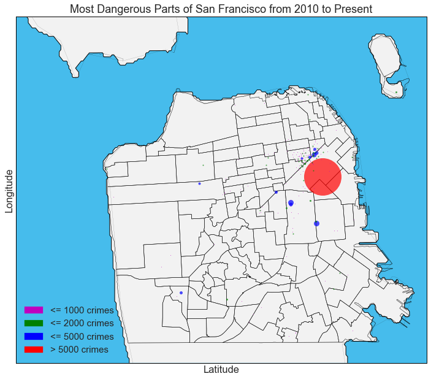

```python
# Make plots larger.
plt.rcParams['figure.figsize'] = (12, 12)

#llcrnrlon lower left corner, urcrnrlon upper right corner
my_map = Basemap(llcrnrlon=-122.56, llcrnrlat=37.7, urcrnrlon=-122.35, urcrnrlat=37.84, resolution="f", projection="merc")
my_map.drawcoastlines()
my_map.drawmapboundary(fill_color='#46bcec')
my_map.fillcontinents(color='#f2f2f2',lake_color='#46bcec')
my_map.drawcounties()

# read in the shape file, where sfneighborhoods is what I will name it
my_map.readshapefile("geo_export_8c430ac2-fab6-412a-8efe-6d7d4ad53402", "sfneighborhoods")

for longi, lata, dist in zip(crime_location.lon, crime_location.lat, crime_location.pddistcount):
    x, y = my_map(longi, lata)
    dot_size = dist / 500
    # >5000 are red, 5000 - 2001 are blue, 2000 - 10001 are green, <1000 are yellow
    if dist <= 1000:
        color = "m"
    elif dist <= 2000:
        color = "g"
    elif dist <= 5000:
        color = "b"
    else:
        color = "r"
    # print x, y, dist, dot_size, color, alpha = transparentcy
    my_map.plot(x, y, color + "o", markersize = dot_size, alpha = 0.7)

m_patch = mpatches.Patch(color='m', label='<= 1000 crimes')
g_patch = mpatches.Patch(color='g', label='<= 2000 crimes')
b_patch = mpatches.Patch(color='b', label='<= 5000 crimes')
r_patch = mpatches.Patch(color='r', label='> 5000 crimes')
sns.plt.title('Most Dangerous Parts of San Francisco from 2010 to Present')
plt.legend(handles=[m_patch, g_patch, b_patch, r_patch], loc = 'lower left')
plt.xlabel("Latitude")
plt.ylabel("Longitude")
```

According the map, the largest amount of crimes are in the Mission Bay (Southern Police Department). Lots of small amounts of crime around the Tenderloin and Mission District (Downtown San Francisco). There are a few large blue dots, which are also part of Mission and Mission Bay of San Francisco. It is also interesting to note that all these areas are areas in San Francisco where rent is cheaper and have high amounts of low-income families living there.

### 3. Are noise complaints and mobile food vendors related?

```python
# get only mobile_food_facility, entertainment, amplified_sound_electronics
noise_unique = pd.read_sql("SELECT Type \
                           FROM noise \
                           WHERE Lat IS NOT NULL \
                           AND Lon > -123 \
                           GROUP BY Type"
                           , db)

noise_complaints = pd.read_sql("SELECT Neighborhood, Lat, Lon, Type \
                               FROM noise \
                               WHERE Lat IS NOT NULL \
                               AND Lon > -123 \
                               AND (Type = 'mobile_food_facility' OR Type = 'entertainment' OR Type = 'amplified_sound_electronics')"
                               , db)

noise_complaints.head()
```

|  | Neighborhood | Lat | Lon | Type |
| --- | --- | --- | --- | --- |
| 0 | Mission Dolores | 37.769148 | -122.424475 | amplified_sound_electronics |
| 1 | Outer Richmond | 37.774201 | -122.484448 | amplified_sound_electronics |
| 2 | South of Market | 37.773292 | -122.411780 | amplified_sound_electronics |
| 3 | Lower Pacific Heights | 37.785036 | -122.441537 | amplified_sound_electronics |
| 4 | South of Market | 37.779203 | -122.402444 | amplified_sound_electronics |

```python
food_truck_location = pd.read_sql("SELECT l.LocationDescription, l.Latitude, l.Longitude, p.Status \
                                  FROM mobile_food_locations l \
                                  LEFT JOIN mobile_food_schedule s ON l.locationid = s.locationid \
                                  LEFT JOIN mobile_food_permits p ON s.permit = p.permit\
                                  WHERE l.Latitude IS NOT NULL \
                                  AND l.Latitude IS NOT 0.0 \
                                  AND p.Status = 'APPROVED'"
                                  , db)
food_truck_location.head()
```

|  | LocationDescription | Latitude | Longitude | Status |
| --- | --- | --- | --- | --- |
| 0 | TOWNSEND ST: 05TH ST to 06TH ST (400 - 499) | 37.774871 | -122.398532 | APPROVED |
| 1 | TOWNSEND ST: 05TH ST to 06TH ST (400 - 499) | 37.774871 | -122.398532 | APPROVED |
| 2 | TOWNSEND ST: 05TH ST to 06TH ST (400 - 499) | 37.774871 | -122.398532 | APPROVED |
| 3 | TOWNSEND ST: 05TH ST to 06TH ST (400 - 499) | 37.774871 | -122.398532 | APPROVED |
| 4 | TOWNSEND ST: 05TH ST to 06TH ST (400 - 499) | 37.774871 | -122.398532 | APPROVED |

For my query, I first selected the latitude and longitide columns from the tables noise and mobile_food_locations.

I grabbed only the columns where the latitude was not null because some latitude columns were empty. I also had to filter it so that the latitude did not contain the number 0.0 because a latitude with that coordinate is out side the boundaries of San Francisco or else it would being plotting points that were very far from the City and County of San Francisco.

For the noise complaints, I filtered them based on the "Type" that I believed were related to food venders. For example, I knew that complaints about construction or major event venue would not be related to food venders because construction is about buildings and vensue music are usually concerts. For the types of noise complaints, I picked mobile_food_facility, entertainment, amplified_sound_electronics. I picked ones that were related to music and entertainment because sometimes food venders do have music playing because they are at a local fair.

For the food truck locations, I only took the locations were the food truck had the Status of APPROVED because if they are approved then they will have permission from the City and Count of San Francisco to park their food truck and sell food. I chose not to pick the unique locations because that way when I plot the food truck location, if the dot is darker, that means there are many food trucks there (overlapping so color darkens). More food truck could mean more noise because more people will be going there to try out all the different food trucks. Of course the noise level of the area would increase if more people are gathered there.

```python
noise_complaints.columns = noise_complaints.columns.str.lower()
food_truck_location.columns = food_truck_location.columns.str.lower()
```

```python
zips = gpd.read_file("geo_export_8c430ac2-fab6-412a-8efe-6d7d4ad53402.shp")
```

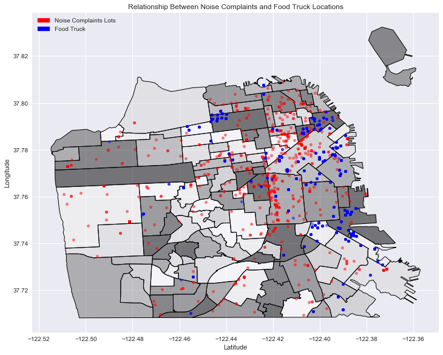

```python
plt.rcParams['figure.figsize'] = (12, 12)

lonlat = [geom.Point(lon, lat) for lon, lat in zip(noise_complaints.lon, noise_complaints.lat)]
lonlat2 = [geom.Point(lon, lat) for lon, lat in zip(food_truck_location.longitude, food_truck_location.latitude)]

noise_complaints = gpd.GeoDataFrame(noise_complaints, geometry = lonlat, crs = {'init' :'epsg:4326'})
food_truck_location = gpd.GeoDataFrame(food_truck_location, geometry = lonlat2, crs = {'init' :'epsg:4326'})
base = zips.plot()

noise_complaints.plot(ax = base, marker = "o", color = "red", markersize = 5, alpha = 0.5)
food_truck_location.plot(ax = base, marker = "o", color = "blue", markersize = 5, alpha = 0.5)
red_patch = mpatches.Patch(color='red', label='Noise Complaints Lots')
blue_patch = mpatches.Patch(color='blue', label='Food Truck')
sns.plt.title('Relationship Between Noise Complaints and Food Truck Locations')
plt.legend(handles=[red_patch, blue_patch])
plt.xlabel("Latitude")
plt.ylabel("Longitude")
```

It appears that there is no relationship between food truck locations and noise because most of the noise complaints are not near a food truck location. However, I do notice that most of the noise complaints are around North Beach, Downtown and Market areas of San Francisco, but the complaints are not near a food truck location. Those are the areas where most of the night life are (bars, clubs, concerts). the noise complaints are not near food trucks possibly because most foods trucks are open during day time hours and not night time. A noise complaint in San Francisco is only vaild if it is past 11pm. Again, I noticed that most of the food trucks are also located in Downtown and Market areas of San Francisco.

### 4. What days of the week do crimes happen the most and what days of the week do crimes happen the least? Are these different across districts/neighborhoods?

```python
crime_by_day = pd.read_sql("SELECT DayOfWeek, COUNT(*) as 'CrimeCount' \
                           FROM crime \
                           GROUP BY DayOfWeek"
                           , db)
crime_by_day
```

|  | DayOfWeek | CrimeCount |
| --- | --- | --- |
| 0 | Friday | 159182 |
| 1 | Monday | 141683 |
| 2 | Saturday | 151941 |
| 3 | Sunday | 139915 |
| 4 | Thursday | 146130 |
| 5 | Tuesday | 144353 |
| 6 | Wednesday | 150197 |

For my query, I selected the days of the week and made a count of how many crimes appear on certain days of the week by doing COUNT(*). This will give me a table with 7 rows for each day of the week with the count of how many crimes have occures on a paticular day of the week.

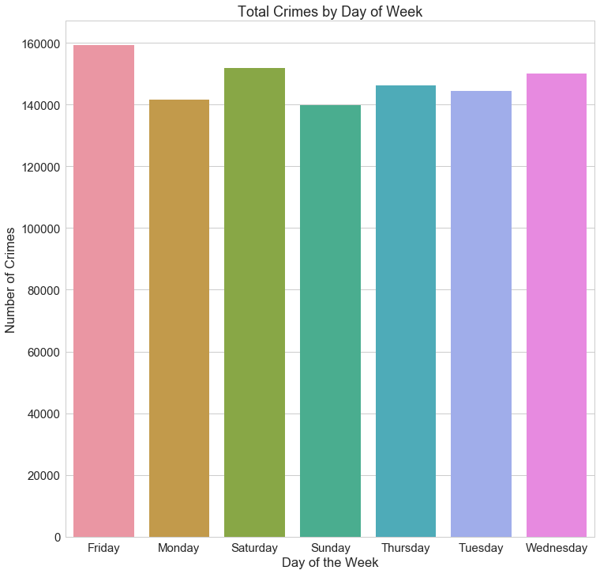

```python
crime_day = sns.barplot(y=crime_by_day["CrimeCount"], x=crime_by_day["DayOfWeek"], data=crime_by_day)
plt.title("Total Crimes by Day of Week")
crime_day.set(ylabel = 'Number of Crimes', xlabel = 'Day of the Week')
plt.show()
```

In the plot above, we can see that the two most popular days to commit a crime are Fridays and Saturdays. This makes intuitive sense because Friday and Saturdays are generall not work or school days so most people go out and most minor crimes in San Francisco are usually people getting drunk and often times this results in people not being able to control themselves. Fridays and Saturdays are also very popular times of the week for people to go out clubbing etc, which may also lead to crimes such as violence.

```python
crime_by_neigh = pd.read_sql("SELECT DayOfWeek, COUNT(*) as 'CrimeCount', PdDistrict \
                             FROM crime \
                             GROUP BY PdDistrict, DayOfWeek \
                             ORDER BY COUNT(*) \
                             DESC"
                             , db)
crime_by_neigh.head()
```

|  | DayOfWeek | CrimeCount | PdDistrict |
| --- | --- | --- | --- |
| 0 | Friday | 30952 | SOUTHERN |
| 1 | Saturday | 29790 | SOUTHERN |
| 2 | Wednesday | 28394 | SOUTHERN |
| 3 | Thursday | 28150 | SOUTHERN |
| 4 | Tuesday | 26614 | SOUTHERN |

In the query above, in order to get the number of crimes by day of the week and by neighborhood, I grouped by both day of the week and Police Department District. The Police Department District is the same as the neighborhood of San Francsico because the City and County of San Francisco has one police department for each neighborhood. So a police department would have documentation of crimes of only the ones that occur within their neighborhood/near by area around that police station. So the more crimes a police station has, then the more crimes occur within that neighborhood/district.

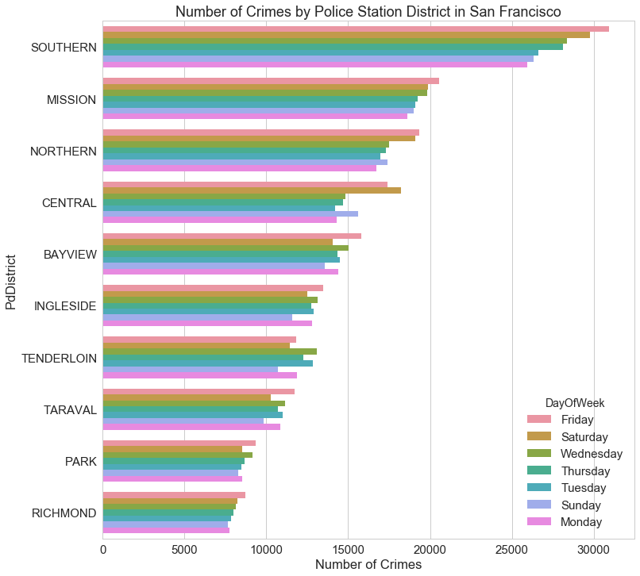

```python
plot = sns.barplot(x="CrimeCount", y="PdDistrict", hue="DayOfWeek", data=crime_by_neigh)
plt.title("Number of Crimes by Police Station District in San Francisco")
plt.xlabel("Number of Crimes")
plt.show()
```

In the plot above, we can clearly see that Southern Police Department, which is located in the Mission Bay, has the most number of crimes, and they are usually on Friday, Saturday and Wednesday. The Mission District has a lot of crimes on Fridays and Saturdays. However, as we go down the plot, we begin to notice that there is no real pattern on what days of the week are most popular to commit a crime when we split up the crimes by neighborhood. Some say the number of crimes generally increase during the holidays (residential theft) and that crimes by states also have no real pattern on why certain days of the week more crimes are commited.

I noticed that neighborhoods such as the Richmond and the Sunset (Taravel) have lower crime rates, but they alos have a higher price to rent ration. It appears that high rent means less crimes. This makes sense as people are genernally willing to pay more to live in a safer area.

### 5. Where are most of the schools in San Francisco located? Does location affect what type of schools there are in the neighborhood? Are there more schools in certain neighborhoods?

```python
public_schools = pd.read_sql("SELECT Name, GradeRange, Category, Entity, Lat, Lon \
                           FROM schools \
                           WHERE GradeRange = '9-12' AND (Entity = 'Community College District' OR Entity = 'SFUSD')"
                           , db)
public_schools.head()
```

|  | Name | GradeRange | Category | Entity | Lat | Lon |
| --- | --- | --- | --- | --- | --- | --- |
| 0 | Asawa, Ruth Asawa San Francisco School Of The ... | 9-12 | USD Grades 9-12 | SFUSD | 37.745316 | -122.448830 |
| 1 | Balboa High School | 9-12 | USD Grades 9-12 | SFUSD | 37.721142 | -122.441399 |
| 2 | Burton, Phillip And Sala Burton High School | 9-12 | USD Grades 9-12 | SFUSD | 37.721546 | -122.406555 |
| 3 | City Arts And Tech High School | 9-12 | USD Grades 9-12 | SFUSD | 37.718784 | -122.424667 |
| 4 | Downtown High School | 9-12 | USD Grades 9-12 | SFUSD | 37.761398 | -122.403702 |

For public schools in San Francisco, children must go to the elementary and middle school that is nearest/closest to them. This means children will likely attend a elementary and middle school that is within the same neighborhood. There is no choice on what elementary or middle school they attend. This is why i filter out the schools by GradeRange of 9-12 (high school level in USA) because once the students get to high school, the students will be assigned a high school based on their choice.

However, in order to get into their first choice they need to have a competative GPA in order to attend. Some high schools have a lower GPA requirment and some have a high GPA requirement. Some high schools, such as charter schools, do not follow the SFUSD application process, but is still a public school, which is why they are under the entity SFUSD.

For example, Lowell High School is a public charter school. They have the same application process as all SFUSD high schools, but they require students to have a completative GPA and write an essay before being considered a valid applicant and then reviewed for acceptance.

```python
private_schools = pd.read_sql("SELECT Name, GradeRange, Category, Entity, Lat, Lon \
                              FROM schools \
                              WHERE Entity = 'Private'"
                              , db)
private_schools.head()
```

|  | Name | GradeRange | Category | Entity | Lat | Lon |
| --- | --- | --- | --- | --- | --- | --- |
| 0 | Adda Clevenger School | K-8 | Independent / Private | Private | 37.753738 | -122.424461 |
| 1 | Alt School - Alamo Square | K-5 | Independent / Private | Private | 37.774788 | -122.430206 |
| 2 | Alt School - Dogpatch 1 | TK-2 | Independent / Private | Private | 37.761177 | -122.388130 |
| 3 | Alt School - Dogpatch 2 | TK-2 | Independent / Private | Private | 37.760662 | -122.387962 |
| 4 | Alt School - Fort Mason | K-8 | Independent / Private | Private | 37.804562 | -122.433907 |

For private schools in San Francisco, anyone can attend them as long as they can pay for the tuition (no aid or whatsoever). This is why I accepted all grade ranges, but filtered out by private entity because I want to see if the location of a private school is affected by the neighborhood.

What we probably expect to see is that neighborhoods with higher housing prices or higher rent prices would have more private schools within the same neighborhood and the lower housing/rent prices would have less private schools nearby.

```python
public_schools.columns = public_schools.columns.str.lower()
private_schools.columns = private_schools.columns.str.lower()
```

```python
# Read in the zipcode database
zips_of_SF = gpd.read_file("cb_2015_us_zcta510_500k.shp")
```

```python
all_zipcodes = pd.read_sql("SELECT RegionName FROM zillow GROUP BY RegionName", db)
all_zipcodes = [str(zips) for zips in all_zipcodes["RegionName"].values]
```

```python
# Remove the zipcodes for South San Francisco
south_city_zip = ['94105', '94080']

for zipcode in south_city_zip:
    all_zipcodes.remove(zipcode)
```

Here I moved all zip codes associated with South San Francisco (AKA South City) because although South City has the words "San Francisco" it is not part of the City and County of San Francisco. It is part of San Mateo County.

```python
#Look for the zipcodes within SF found withing the list above and take the two columns of interest.
zips_of_SF = zips_of_SF.loc[zips_of_SF["ZCTA5CE10"].isin(set(all_zipcodes))]
zips_of_SF = zips_of_SF.sort("ZCTA5CE10").reset_index(drop=True)
zips_of_SF = zips_of_SF[["ZCTA5CE10", "geometry"]]

# Reset the index to later merge with the other dataframe.
ratio_rent_zip = ratio_rent_zip.sort("Zipcode").reset_index(drop=True)

# Merge the two dataframes based on the sorted zipcodes
# Want to get the polygon and the price on the same data frame.
df_merged = pd.concat([zips_of_SF, ratio_rent_zip["Price to Rent Ratio"]], axis=1)
```

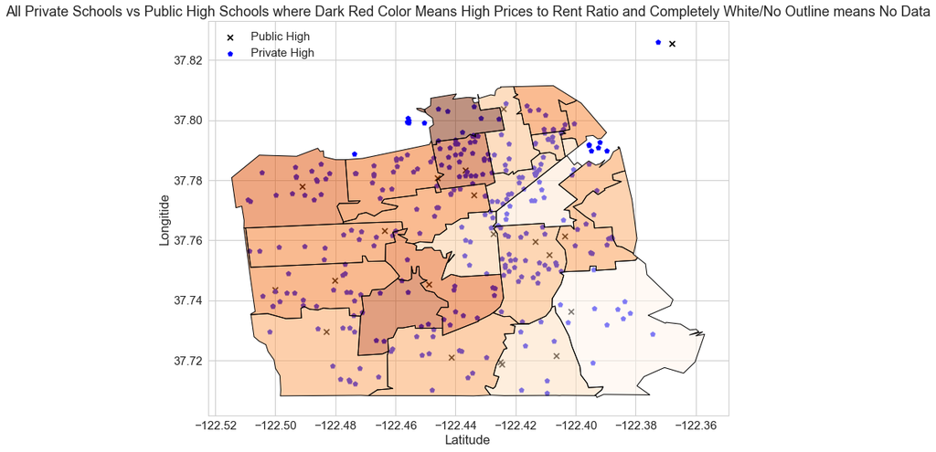

```python
color_plot = df_merged.plot(column='Price to Rent Ratio', colormap="Oranges")
public_schools = plt.scatter(public_schools["lon"], public_schools["lat"], marker='x', color = 'black')
private_schools = plt.scatter(private_schools["lon"], private_schools["lat"],marker='p', color = 'blue')

plt.title("All Private Schools vs Public High Schools where Dark Red Color Means High Prices to Rent Ratio and Completely White/No Outline means No Data")
plt.legend((public_schools, private_schools),
           ('Public High', 'Private High'),
           scatterpoints=1,
           loc='upper left',
           fontsize=15)
color_plot.set(ylabel = 'Longitide', xlabel = 'Latitude')
plt.show()
```

In the map above, we see two floating points, one public and one private high school. Although the map does not show, that is actually the location of Treasure Island. Treasure Island is part of the City and County of San Francisco.

As we can see on the map, there is no relationship or correlation between private school location and price to rent ratio by neighborhoods. There is no real patter to where private school locations are, but the demand for private schools have been steadly increasing since 1930's (Barrow). Since private schools do not recieve any type of funding from the Government, usually a new private school needs demand/funding from public before a new one can open. Some also believe that the growing population of private schools are to force competition between public and private schools by allowing parents to have more options in private schools than high schools. Often times private schools are said to offer a higher quality of education than publics schools because of the saying "what you pay is what you get".

We can also see that high schools appear to be scattered around San Francisco. Although students in San Francisco are not reuqired to attend a high school within the same neighborhood as them, we can see that there is about 1 high school per zipcode/neighborhood and that the price to rent ratio does not affect where a high school is placed. This could have been done on purpose, as possibly students attended high schools based on neighborhoods back then. Or the public high schools were first build by demand of a growing San Francisco.

### Resources

Barrow, Lisa. Private School Location andNeighborhood Characteristics. Federal Reserve Bank of Chicago. December 2002. Web. March 2017.